# JLC 245 Final Project

Melanie Klein

2025-05-06

# Data

```
##                   project2 project3 project4 project5
## Washington DC            0        0        0        0
## San Bernardino CA        1       10       14       17
## Sacramento CA            4       20       14       17
## Baltimore MD             2       20       13       15
## San Francisco CA         3        2       12        1
## Atlanta GA               5        1        2       17
## Phoenix AZ              30        4       22       15
## Dallas TX               10        5       14       15
## Philadelphia PA         15        3       20       10
## Kansas City MO          15       20        5       10
## Denver CO               20       20        4        6
## Portland OR             10       20        3        2
## Seattle WA              15       10        1        3
## New York City NY        20       30       20        5
## Los Angeles CA          30       30       14        4
```

# Analysis

Atlanta, GA is the most similar city to Washington, D.C. It is in the same cluster and appears closest to Washington, D.C. in the visualization. When analyzing demographic data from the Census Bureau’s American Community Survey, Atlanta ranks as the most similar city to Washington, D.C. When analyzing hate crime statistics using FBI data, Atlanta ranks the second most similar city to Washington, D.C.

Baltimore, MD is somewhat similar to Washington, D.C. Although it is geographically very close, it belongs to a neighboring cluster in the visualization. When analyzing police-involved shootings from the Washington Post’s Fatal Force Database, Baltimore ranked the second most similar city to Washington, D.C. However, when analyzing hate crime statistics using FBI data, Baltimore ranked 13th in similarity to Washington, D.C. out of 34 potential cities.

Phoenix, AZ is not similar to Washington, D.C. It is geographically distant and located far away in a separate cluster of only two cities in the visualization. When analyzing hate crime statistics from FBI data, Phoenix ranked 22nd in similarity to Washington, D.C. out of 34 potential cities. Additionally, when analyzing demographic data from the Census Bureau’s American Community Survey, Phoenix ranked the fourth most similar city to Washington, D.C. Furthermore, when analyzing mental health and substance abuse metrics from the Big Cities Health Inventory Data Platform, it is estimated that Phoenix ranked 15th in similarity to Washington, D.C. out of 34 potential cities.

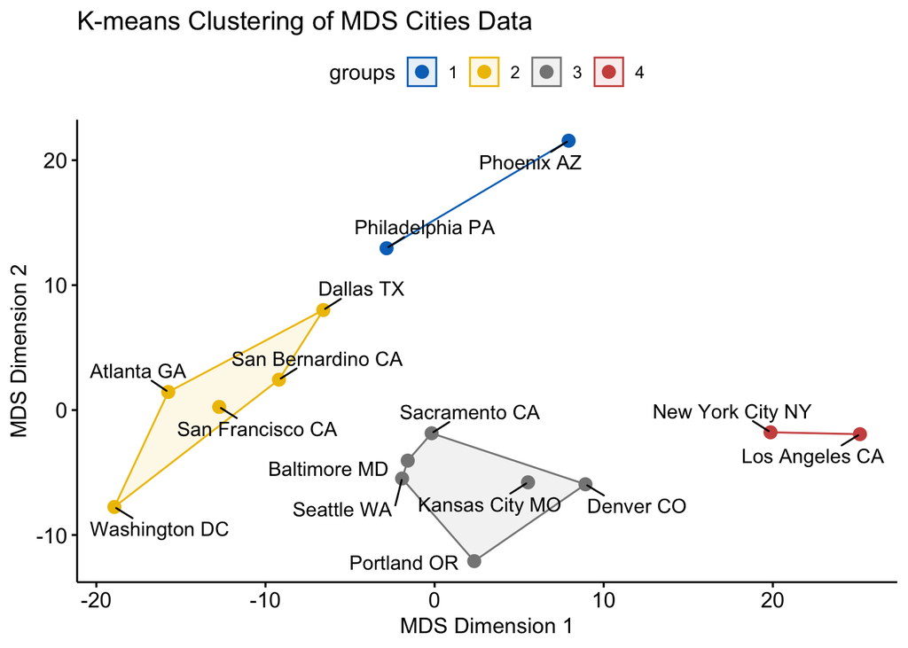